# Your Digest for Thursday, Dec 28, 2023 12:59 PM

| Type | Cutoff for abnormal |
| --- | --- |
| Total Cholesterol | >200 mg/dL |
| TG | >150 mg/dL |
| HDL | <40 mg/dL male, <50mg/dL female |
| LDL | >100 (but depends on risk) |
| VLDL |  |

mainly ⬆ cholesterol

Mainly ⬆TGL

*Disease which have 'O'*

*Mnemonic: ABCDEF_H*

Nephr*o*tic syndrome

**Alcohol**

Hyp*o*thyroidism

Beta blockers (*non selective ones* but not carvedilol)

Ch*o*lestasis

CKD

*O*CP

Diabetes and Diuretics (*Thiazides*),  
Diet ( ⬆refined carbs)

"*O*verweight": Both weight *gain* & *Anorexia*

Estrogen (unopposed)

Gammaglobulinopathy

Hypothyroidism is common to both

Hepatic disease, *hypothyroidism*, HIV

Pregnancy, PCOS,

Glucocorticoids

Glucocorticoids

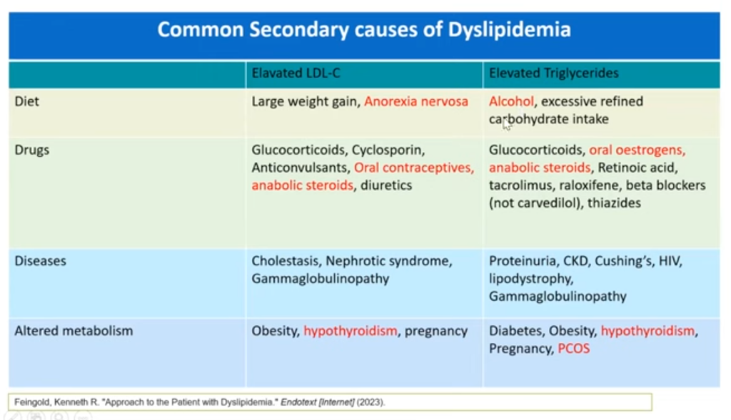

- **lipoprotein a**: A lipoprotein present on LDL particles which increases atherogenicity. It is NOT influenced by diet; only genetically determined. Once in a life time check is enough to assess levels and ASCVD risk. Levels are *not reduced by statins*. No evidence for starting Lp(a) lowering PCSK9i drugs for primary prevention.
- Benefit of statins is a **class effect**: no one statin is more effective than the others.
- High intensity therapy: > 50% reduction in LDL-c
- Moderate: 30 to 49% reduction;
- Low intensity : <30% reduction

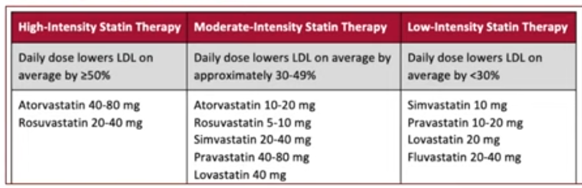

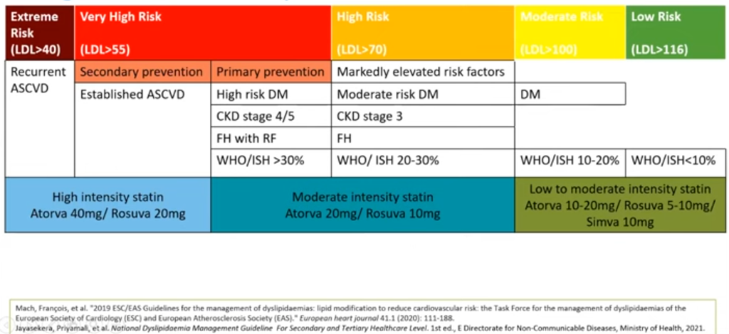

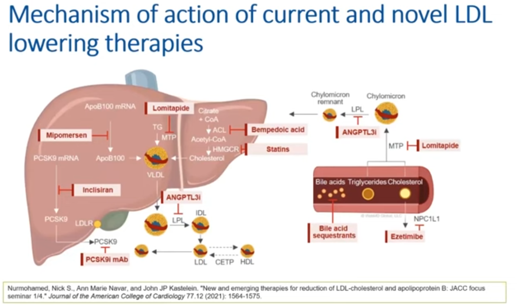

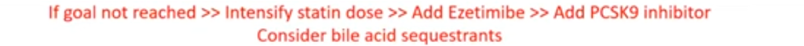

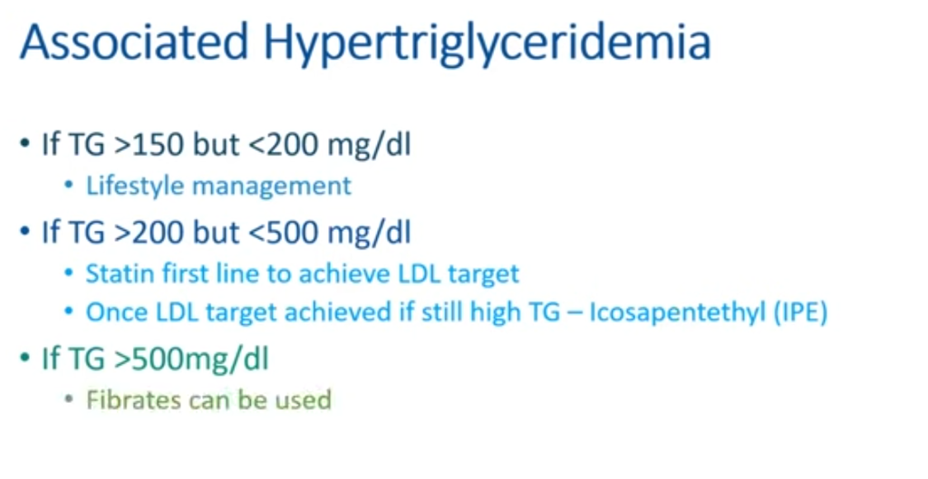

##### Side effects of statin therapy

- Overall incidence is low (<2%)
- Significant odds ratios have been found for
  - **liver enzyme elevation** - true hepatotoxicity, liver failure are very rare.
  - **Muscle related *symptoms***
  - Rhabdomyolysis / myositis / myopathy is a known side effect (but rare)
  - They can cause new onset diabetes.
  - Reversible proteinuria of *tubular origin*. (not a big deal)
- Can be combined with statins and PCSK9 inhibitors.
- Can be used as monotherapy
- Can also rarely cause rhabdomyolysis and liver enzyme impairment
- Category C in pregnancy